# How did Future Zahir Wilburn change Ciara and Future?

Jess Mathew

September 16, 2019

[figure not shown]

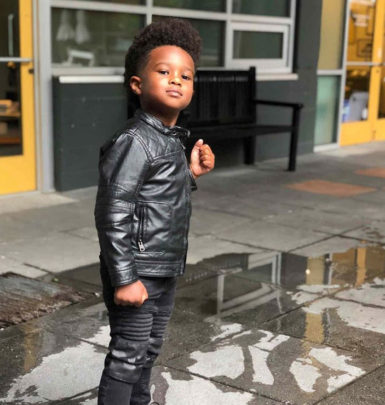

[output not shown]

# Background

Future Zahir Wilburn is the son that Ciara and Future had together. This report will be an analysis on how the birth of that child affected Ciara and Future. My original premise was to see how parenthood affected men and women differently, but I think it would be even more interesting to see how the birth of the same child affects the parents of that child.

Using the processed lyrics data, I filtered out for Future and Ciara. I then did my own research and found that Zahir was born in 2014. Using this information, I split the lyrics of Future and Ciara into two grops, one prior to 2014 and the other contains lyrics for 2014 and beyond.

People always say, “Being a parent changes you in so many ways. I can’t explain it, you just have to experience it for yourself.” Well, let’s see if an analysis into song lyrics can give us answers that no parent has been able to offer thus far!

# Question 1: How does parenthood change language choices?

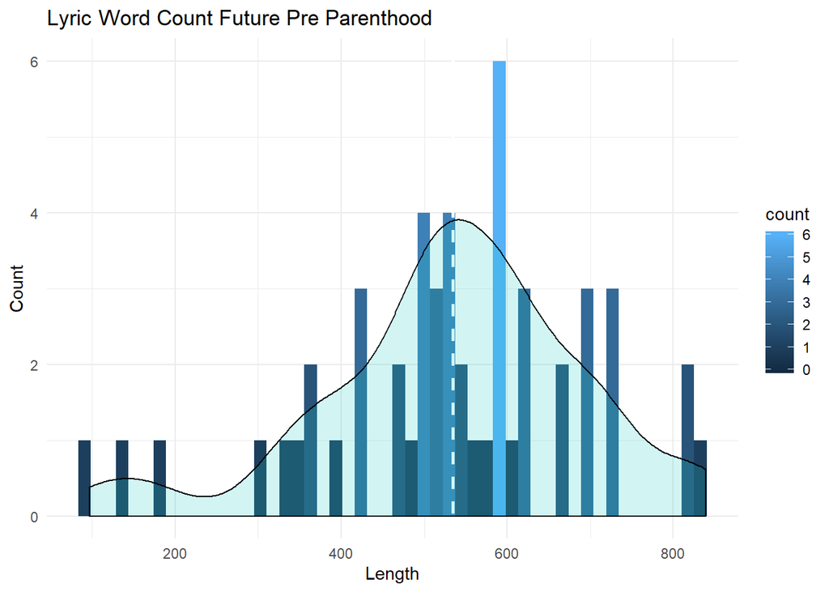

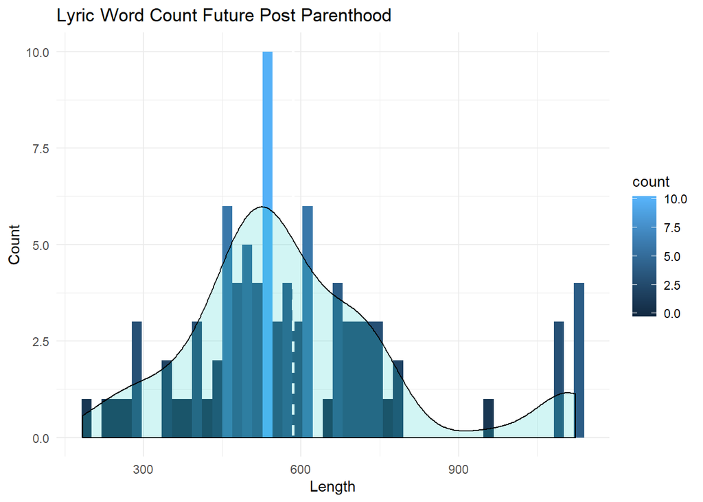

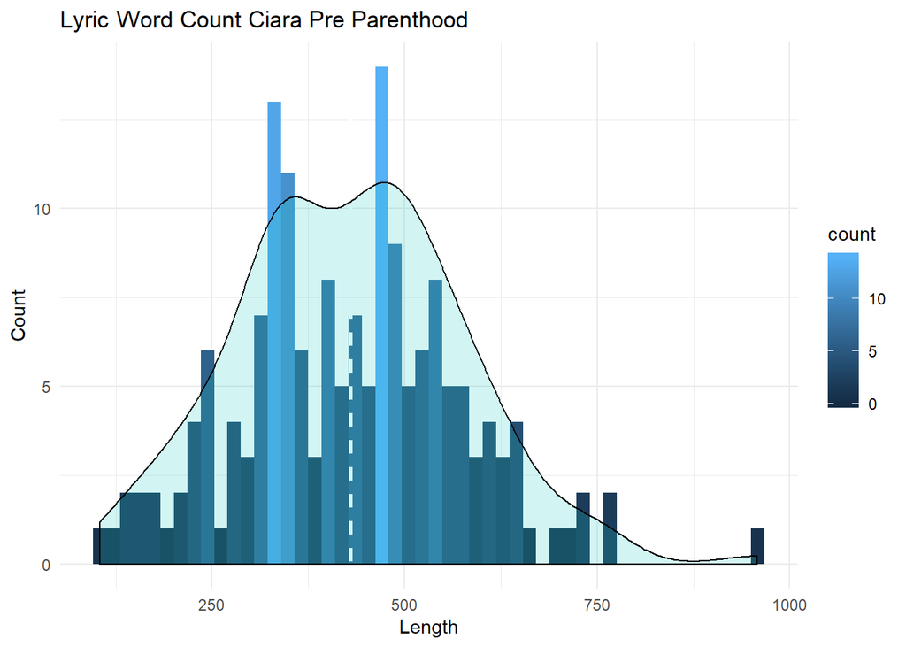

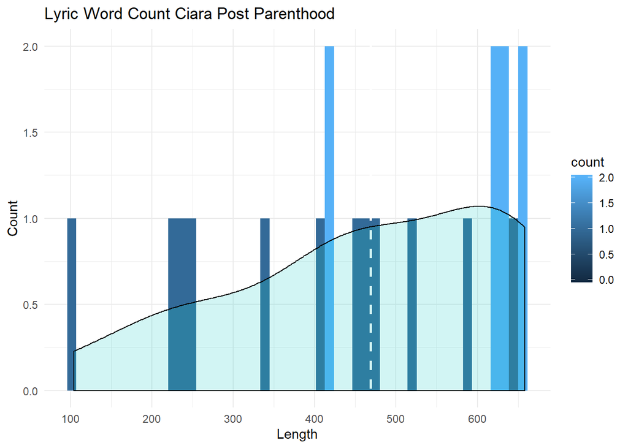

Conversely, it seems that parenthood had no substational affect to Ciara’s music in that regard. She did have a few songs that ended up being on the longer side, after Zahir was born, however her overall average length stayed right about the same.

On a basic preliminary analysis, it seems that Future had more lengthy and meaningful messages to give to his audience after he became a father to Zahir.

Now we will take a look at the actual content in the lyrics themselves. This leads us to our second question.

# Question 2: How does parenthood change interests?

We will first compare the lyrics of Future pre and post parenthood.

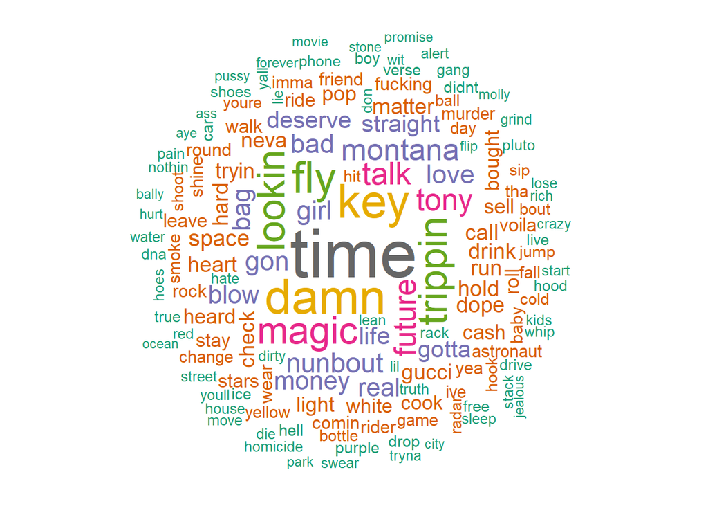

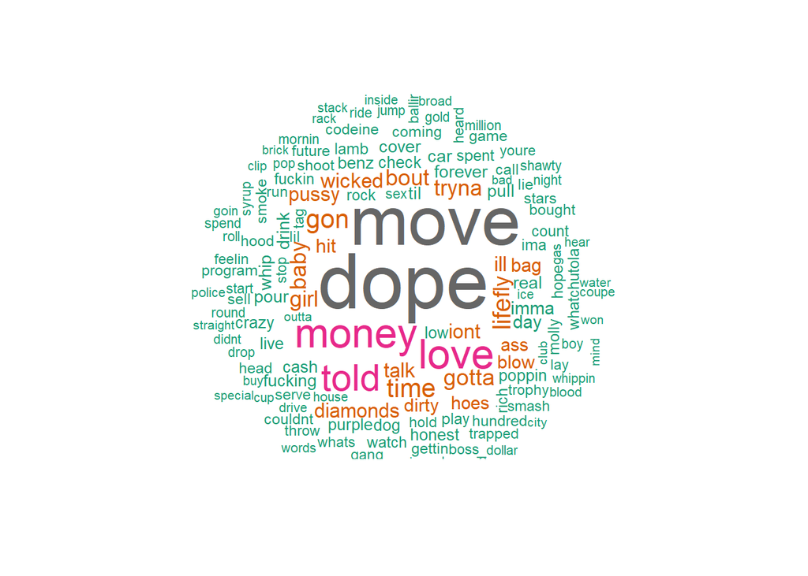

Comparing the word clouds, we see that post parenthood, Future talks more about ‘move’s, ’money’, ‘love’, ‘diamonds’, ‘bags’ and ‘baby’. This seems to lend itself to the idea that after having a child, Future wants to be able provide for and protect his child and the mother of his child. Now let’s take a look at the content in Ciara’s world cloud to see if any insights can be drawn from that.

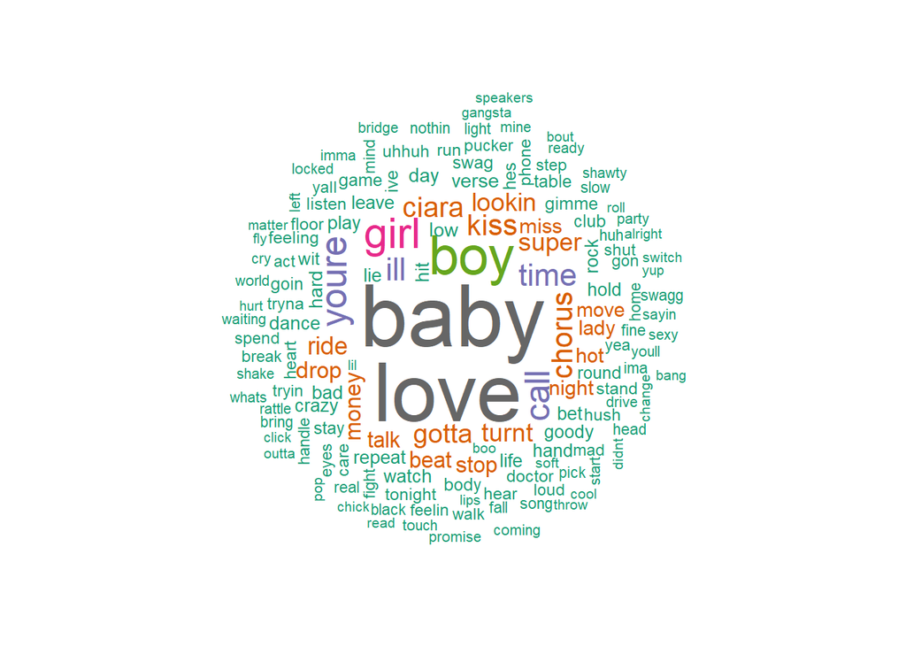

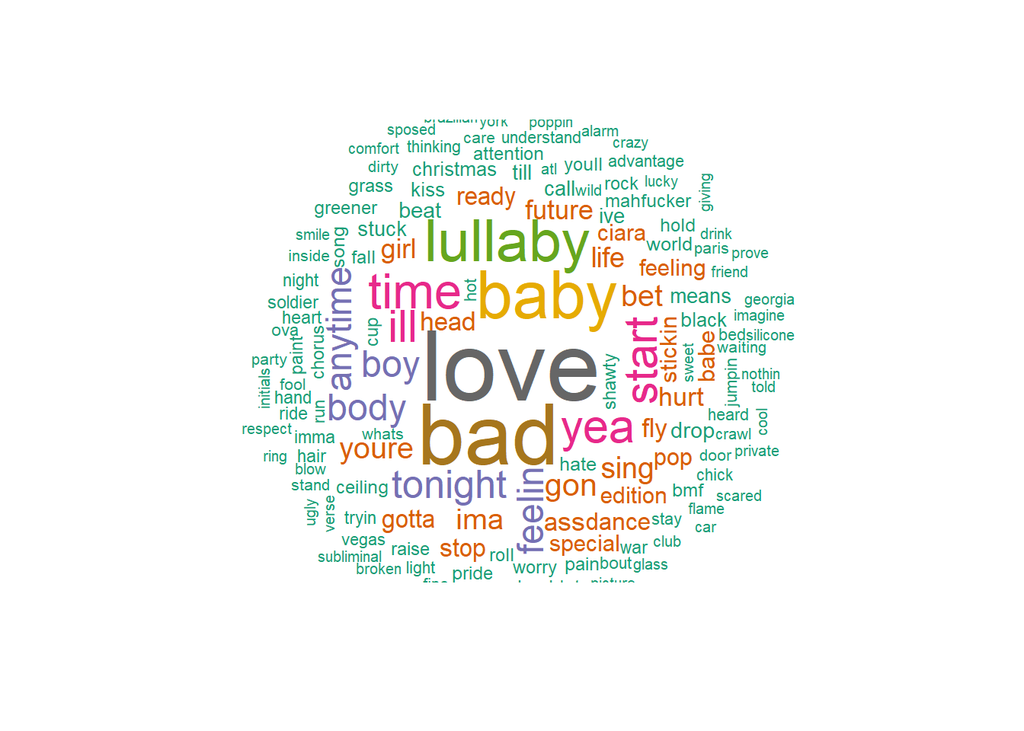

Interestingly, the most used word, prior to Zahir, was ‘baby’. Assuming that this was related to a baby in the sense of a significant other. While post parenthood, the most prominent word is actually ‘love’. Another thing worth noting is that the word’lullaby’ is used prominently after childbirth as was the word ‘life’. “Lullaby’ in particular siginifies sings songs to a baby to help them fall asleep. So post parenthood, Ciara’s song seem to have a more motherly touch.

Looking into this further causes us to ask a third question!

# Question 3: How does parenthood change overall mood?

We will first perform sentiment analysis on Future’s song lyrics to see if there is a difference in the overall mood of the songs from pre parenthood or post parenthood.

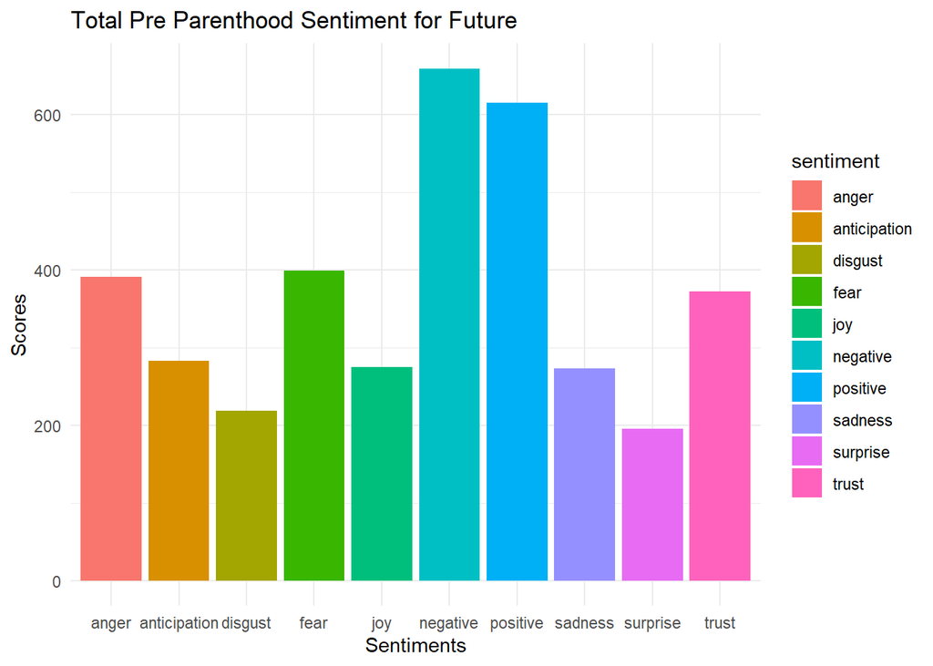

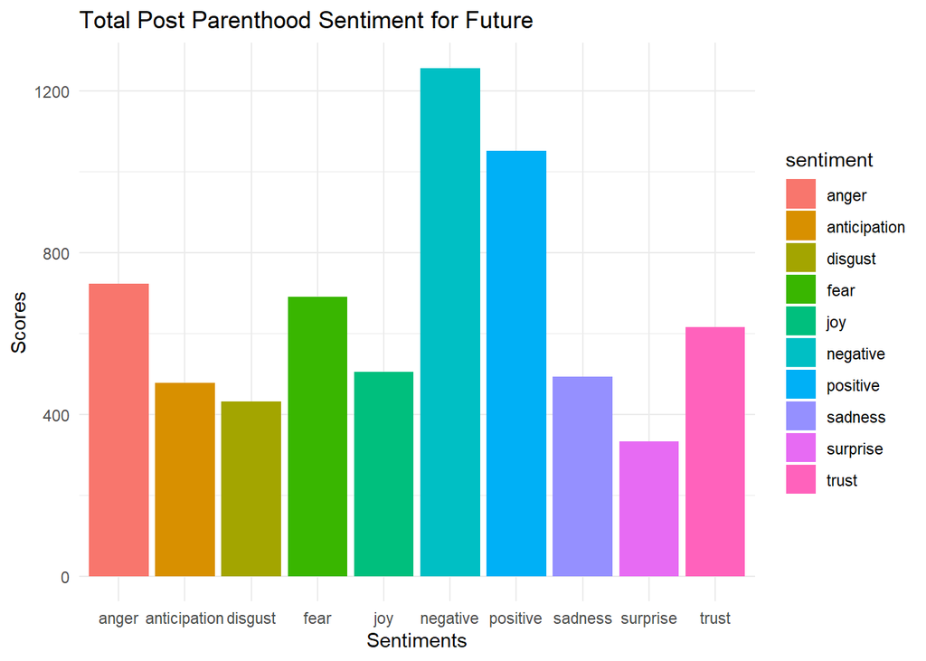

There are some interesting pieces of information available here. We can see that the ‘negative’ sentiments rose post children. This correlates well with the idea that male artists view children as a burden and not a source of emotional joy. For male artists, children seem to be a point of negativity. It seems to be a running trend that relationship male music artists have with their children is strictly financial, viewing them more as a mistake than a blessing.

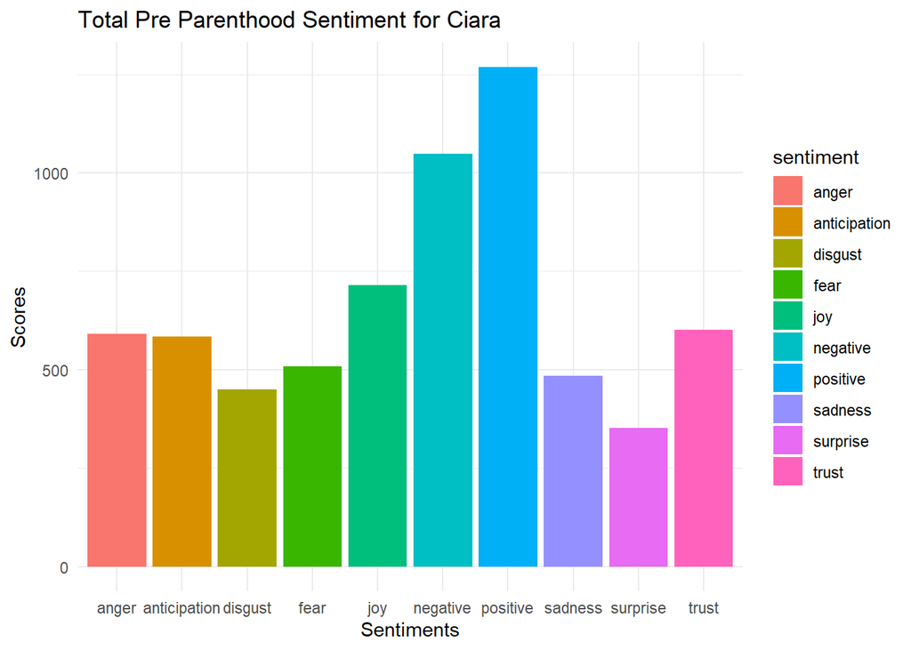

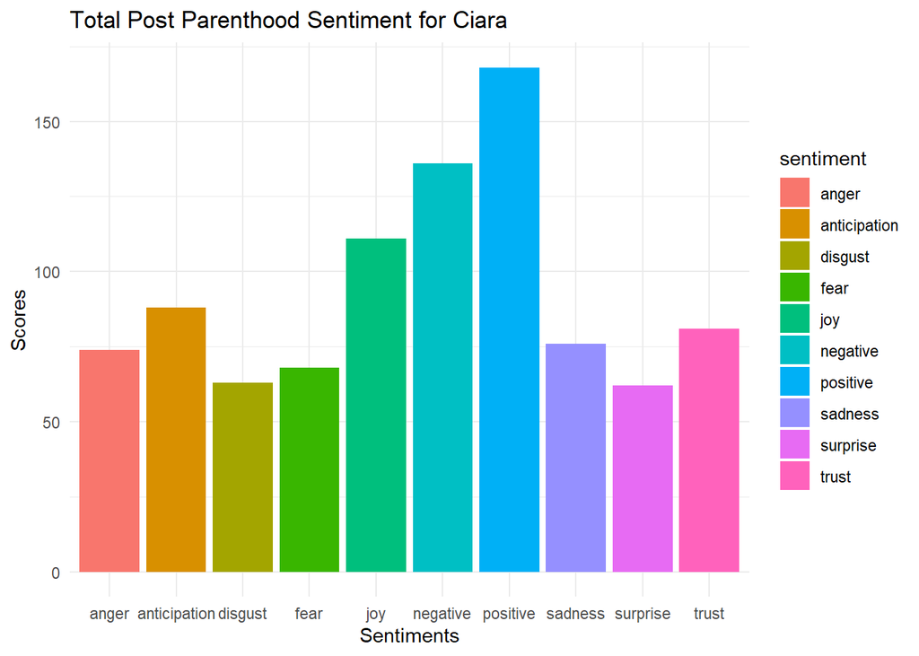

# Conclusions

Overall, it seems to be that Future Zahir Wilburn had a positive effect on Future and Ciara.

Looking at Future, we can see that his lyrics became lengther and he spoke of meaningful things that related to sustaining a family. He talks about ‘money’, ‘diamonds’, ‘love’, ‘move’s; and ’life’ as his main topics post parenthood. While he also had an overall increase in the ‘negative’ sentiment, this can be attributed to the common culture of male artists to view children as more of a burden financially than a blessing emotionally. But the underlying theme for him is that he will provide for his family.